# Coding Outreach Group Summer Workshop - Visualizing Data in R

Content creator: William J. Mitchell

07/08/2021

# Introduction

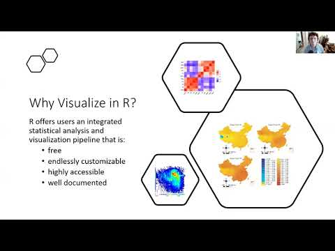

# 0.0 An R Markdown Primer

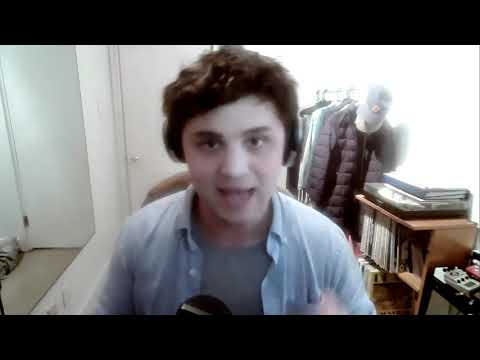

This is an R Markdown script. Much like a typical R script, it contains code documenting your process, such that any other individual could reproduce your work. However, unlike typical R scripts, R Markdown allows us to narrate the process (much as I’m doing now). The different types of text (narration and code) usually appear in different colors so you can tell the difference; though, what color it appears as for you might differ based on your settings.

A typical R script will interpret any text that you include as a command to be carried out, unless otherwise marked by a hashtag (#). The output will appear in your R Studio Console window. By output, we just mean the product, sum, or status of whatever calculation or item you are asking R to compute or show for you.

R Markdown can be a little more complicated, but you also have a lot of control over how commands, text, and output are displayed. Ultimately, because of this additional control, I find R Markdown scripts more intuitive and easy to follow (though not everyone feels the same). The output of any commands you enter into an R Markdown script typically appears just below the script that created it. We can read it in the console if we prefer, but it’s nice having all the information we want in one window (this one). We can also minimize output and text that we don’t want to look at in the moment by clicking on the arrow next to the line count on the left side of the window.

In order to tell R when you want it to treat something as a command in R Markdown, you use these ``` symbols (which are admittedly a little annoying to create on a keyboard. I usually just copy and paste them) followed by “{r }”. Below that, we enter the command(s) we want to run, and then we close it all out with those hard-to-create symbols again. Next to “{r }”, we can add descriptions of what is happening within that block. Let’s look at this example below :

```r
# This is an example of a command. I use the three little dash marks, followed by {r } to let R know I want to give it a command. I can describe what the command is after the r (Like I did with "Example"), though, it's not necessary to do so. Also, notice, much like a typical R script, I can use a # to let R know that this text should not be consider a command. If I were to press "Enter" and go down a line, I can have it start paying attention again and calculate the sum of 2 and 4.

Value <- 2 + 4
Value
```

```
## [1] 6
```

```r
# to calculate that line in R Markdown, I can press COMMAND + ENTER, or to run all of the commands within this block, I can press the green right facing arrow in the upper right corner of the block.
```

If you pressed the “Run” command, hopefully you saw a little box pop up just below your block that said “[1] 6”. If you want to export the output, whatever it may be, to a new window, simply click the first icon of the the three in the upper right corner of the output box. To minimize, click the second, and to delete, press the third. Note that deleting the output does not affect the related code.

Also of note, the down-facing arrow (second icon in the upper right corner of the code block) will tell R “Run all of the blocks of command that I have before this block.” It can be helpful if you make a mistake and don’t want to rerun all of the previous blocks one by one to get back to where you were. It also makes your code very easy for other people to run. They can quite literally do it with the click of a button! If we click the cog icon in the same tray, we can access the output options and manipulate where output appears and what it looks like, but that’s beyond the scope of this review. Let’s go ahead and try it below; if you click on the “Run all” function for the Example 3 block, Example 1 and Example 2 should rerun and run, respectively:

```r
(Value * 3) + 2
```

```
## [1] 20
```

```r
(Value/10)
```

```
## [1] 0.6
```

R Markdown scripts will allow us, once we are done, to compile all of our work, or “knit” it, and share it as either an interactive pdf or html document which others can follow. They are very helpful if you want to run a stat coding blog, or, say, teach a class on visualizing data in R. I’m not going to go much deeper into the setup of R Markdown, but I have included a very helpful reference in the course materials for those interested.

Of note for those familiar with R, but new to R Markdown: A few functions work differently in R Markdown, relative to an R script. For example, in a typical R script, we could set our working directory using the setwd function and it would remain the working directory until otherwise specified. R Markdown does not play nice with the setwd command for whatever reason, so I’ve found the simplest option is to just recall the file pathway whenever you want to load or save a file. The others aren’t super relevant for this presentation, but something to keep in mind if anyone gets converted to the cult of R Markdown.

Now that we’ve got that out of the way, let’s get started!

# 0.5. Workshop Setup

[figure not shown]

Let’s get started by first loading the packages that we’re going to need in this workshop. I have them listed below. Those new to R should download all of the packages by running the Package Installation block. Again, as a reminder for those of you new to R Markdown, you can just click the green “play” arrow in the upper right hand corner. If you already have these packages, you can skip this step. If you are unsure if you do, I’d recommend running it anyway; it won’t hurt anything:

```r
# install.packages("effects")
# install.packages("GGally")
# install.packages("ggplot2")
# install.packages("ggpubr")
# install.packages("ggthemes")
# install.packages("interactions")
# install.packages("psych")
# install.packages("plyr")
# install.packages("RColorBrewer")
# install.packages("sjPlot")
# install.packages("skimr")
```

Now that the packages are installed, let’s let R know which packages we want it to have ready:

```r
library(effects)
library(GGally)
library(ggplot2)
library(ggpubr)
library(ggthemes)
library(interactions)
library(psych)
library(plyr)
library(RColorBrewer)
library(sjPlot)
library(skimr)
```

Next, I’m going to specify the working directory in which I will be storing the figures that we generate. You should specify whatever filepath you’d like.

```r
  Plots.Dir <- "C:/Users/Administrator/Google_Drive/COG/cog_summer_workshops_2021/data-visualization-in-r/Plots/"
```

Lastly, we’re going to load our first of three dataframes. This first dataframe contains data from a project I’d recently finished looking at the representational similarity of affect in specific brain regions from both children and adults. Once again, you may need to modify the filepath here to designate where ever you have the dataframe stored:

```r
   load("C:/Users/Administrator/Google_Drive/COG/cog_summer_workshops_2021/data-visualization-in-r/Dataframes/df1.rda")
```

There are 8 variables in this dataset, and we’re primarily going to focus on pattern similarity, captured by Correlation.fz, region of interest, captured by ROI, age group, captured by Age.Group, and stimuli valence, captured by Valence.Pair. The function below (from the psych package) just gives us a brief overview of our variables.

```r
   describe(df)
```

|  | vars | n | mean | sd | median | trimmed | mad | min | max | range | skew | kurtosis | se |
| --- | --- | --- | --- | --- | --- | --- | --- | --- | --- | --- | --- | --- | --- |
| Participant* | 1 | 11340 | 2.300000e+01 | 12.9877458 | 23.0000000 | 23.00000000 | 16.3086000 | 1.0000000 | 45.000000 | 44.000000 | 0.00000000 | -1.2015030 | 0.121962763 |
| ROI* | 2 | 11340 | 2.000000e+00 | 0.8165326 | 2.0000000 | 2.00000000 | 1.4826000 | 1.0000000 | 3.000000 | 2.000000 | 0.00000000 | -1.5002645 | 0.007667733 |
| Age.Group* | 3 | 11340 | 1.444444e+00 | 0.4969259 | 1.0000000 | 1.43055556 | 0.0000000 | 1.0000000 | 2.000000 | 1.000000 | 0.22357722 | -1.9501852 | 0.004666434 |
| Age.MOs | 4 | 11340 | 1.951311e+02 | 119.6428760 | 124.2000000 | 184.57361111 | 78.8743200 | 58.0000000 | 528.000000 | 470.000000 | 0.61168016 | -0.7125791 | 1.123518730 |
| Valence.Pair* | 5 | 11340 | 2.000000e+00 | 0.8165326 | 2.0000000 | 2.00000000 | 1.4826000 | 1.0000000 | 3.000000 | 2.000000 | 0.00000000 | -1.5002645 | 0.007667733 |
| Correlation | 6 | 11340 | 2.181645e-01 | 0.3235434 | 0.2409689 | 0.23180574 | 0.3342982 | -0.9435149 | 0.970820 | 1.914335 | -0.38061629 | -0.2342897 | 0.003038267 |
| Correlation.fz | 7 | 11340 | 2.496317e-01 | 0.3841263 | 0.2458024 | 0.24959193 | 0.3641556 | -1.7691382 | 2.106361 | 3.875500 | -0.02435637 | 0.5669258 | 0.003607177 |
| Age.MOs.z | 8 | 11340 | -1.134300e-16 | 1.0000000 | -0.5928570 | -0.08824178 | 0.6592479 | -1.1461703 | 2.782187 | 3.928358 | 0.61168016 | -0.7125791 | 0.009390603 |

Now that setup is done, let’s begin!

# 1.0. Quick Assumption Visualizations

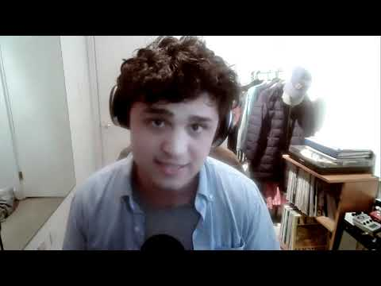

One of the first thing any good researcher should do once their data is formatted for analysis is examine whether the data meets the assumptions necessary for the tests they want to run. This often involves visual inspections, and R has a lot of packages to make this simple.

We’re going to start with a function that is not visually focused, per se, but one that’s very simple and that I find very useful for its integration of basic visual information and summary statistics: the skim function in the skimr package.

```r
skim(df)
```

Data summary

| Name | df |
| --- | --- |
| Number of rows | 11340 |
| Number of columns | 8 |
| _______________________ |  |
| Column type frequency: |  |
| factor | 4 |
| numeric | 4 |
| ________________________ |  |
| Group variables | None |

**Variable type: factor**

| skim_variable | n_missing | complete_rate | ordered | n_unique | top_counts |
| --- | --- | --- | --- | --- | --- |
| Participant | 0 | 1 | FALSE | 45 | C20: 252, C20: 252, C20: 252, C20: 252 |
| ROI | 0 | 1 | FALSE | 3 | AMY: 3780, NAc: 3780, vmP: 3780 |
| Age.Group | 0 | 1 | FALSE | 2 | Chi: 6300, Adu: 5040 |
| Valence.Pair | 0 | 1 | FALSE | 3 | Neg: 3780, Pos: 3780, Neu: 3780 |

**Variable type: numeric**

| skim_variable | n_missing | complete_rate | mean | sd | p0 | p25 | p50 | p75 | p100 | hist |
| --- | --- | --- | --- | --- | --- | --- | --- | --- | --- | --- |
| Age.MOs | 0 | 1 | 195.13 | 119.64 | 58.00 | 94.00 | 124.20 | 288.00 | 528.00 | ▇▁▅▁▁ |
| Correlation | 0 | 1 | 0.22 | 0.32 | -0.94 | 0.00 | 0.24 | 0.46 | 0.97 | ▁▂▆▇▂ |
| Correlation.fz | 0 | 1 | 0.25 | 0.38 | -1.77 | 0.00 | 0.25 | 0.50 | 2.11 | ▁▁▇▂▁ |
| Age.MOs.z | 0 | 1 | 0.00 | 1.00 | -1.15 | -0.85 | -0.59 | 0.78 | 2.78 | ▇▁▅▁▁ |

As you can see, skimr will summarize the variables in my whole dataframe and group them by type. What’s notable for us is that for the numeric variable type (at the bottom), it will automatically generate mini histograms to examine data distributions, which is really helpful to glance at.

However, miniature histograms might not always be the best means of visually inspecting our data, so we’re going to quickly move on to a function that is far more visually oriented. The ggpairs function within the GGally package will allow us to specify a few variables of interest and examine how the datapoints of those variables are distributed within the context of each other. It will automatically identify different data types, like factors, continuous variables, etc. and make the reasonable selection for how to display the data. We’re gonna try it with a few variables now and you’ll see what I mean. Note of warning: this function could take a very long time to run if you have a big dataframe and lots of variables. The first case is true for us now, but not the second case, so we should be fine.

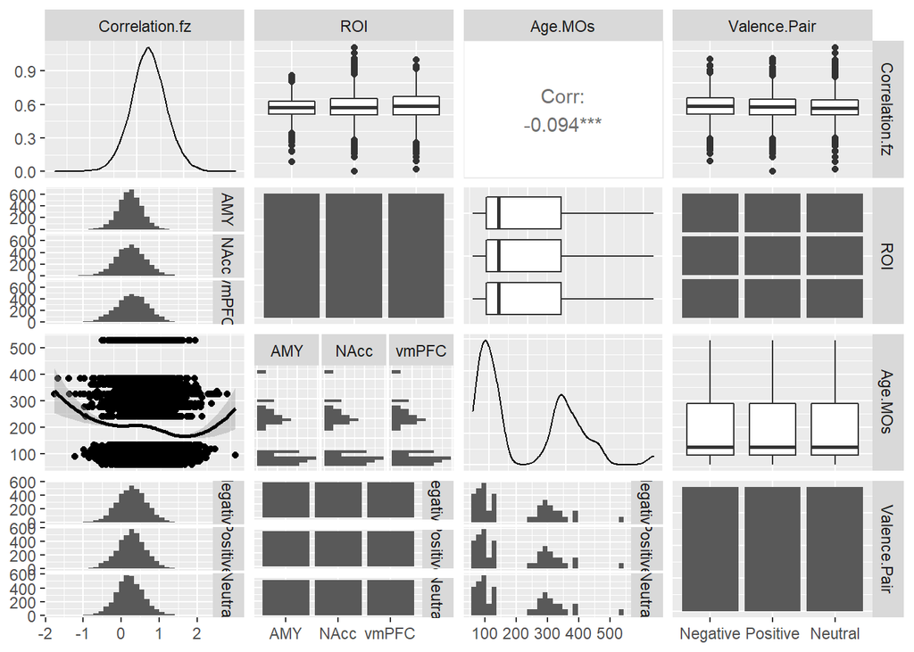

```r
ggpairs(data=df[c("Correlation.fz", "ROI", "Age.MOs", "Valence.Pair")],
                       lower = list(continuous = wrap("smooth", method = "loess")), showStrips=TRUE)
```

While both skimr and ggpairs are highly convenient for taking a quick look at the distribution of a lot of variables at once, their resolution, necessarily, leaves a little to be desired. That is to say these are not well suited for examining complex data that might hide nuances with broad binning. So we’re gonna use commands to single out specific variables of interest.

Base R’s hist function does an excellent job of demonstrating frequency distributions:

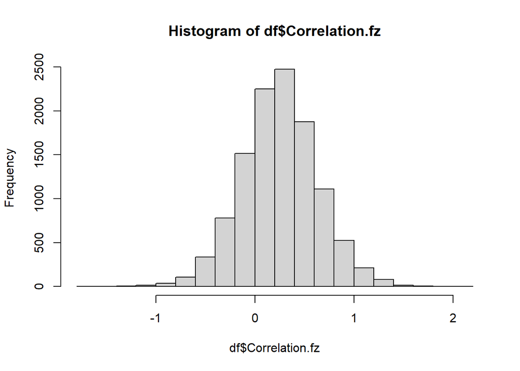

```r
hist(df$Correlation.fz)
```

and this will suit most of our needs. We could get a little more fancy with gghistograms from the ggpubr package if we like, where main specifies the title of the plot, and xlab specifies the label on the x axis:

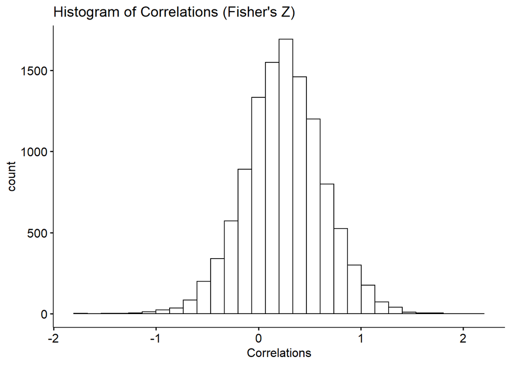

```r
gghistogram(df$Correlation.fz,
            main = "Histogram of Correlations (Fisher's Z)",
            xlab = "Correlations")
```

But for how most researchers use histograms, honestly, you can’t really go wrong with either. The ggpubr package has a lot of other great diagnostic and descriptive visualization options in it. For example, if we want to further examine the normality of a distribution, we can always use the ggqqplot function

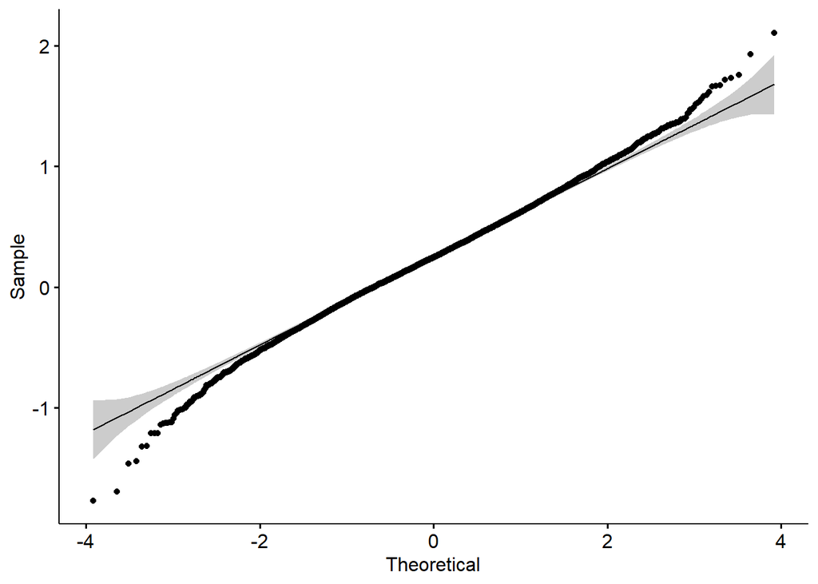

```r
ggqqplot(data = df,
         x = "Correlation.fz")
```

The problem we have with this plot, though, is we again don’t have quite enough resolution. In the study this data is pulled from, we have different conditions by valence, so we should really be looking at whether each valence group is distributed normally. ggqqplot makes that simple to do with something called facet wrapping (Keep note of that, we’ll come back to it when we get to ggplot). In this command below, we’re specifing the dataframe and variable again, but then we’re also telling ggpubr what we want the plot to look like with ggtheme and specifying that we’d like it to analyze the distribution of values within each category of the variable Valence.Pair.

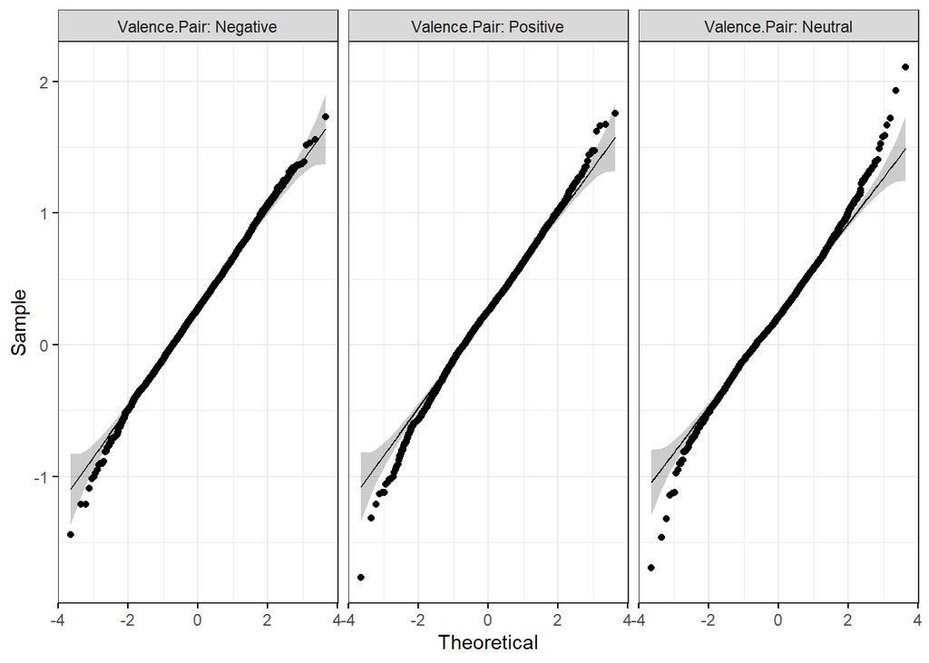

```r
ggqqplot(data = df,
         x = "Correlation.fz",
         ggtheme = theme_bw()) +
         facet_grid( ~ Valence.Pair, labeller = "label_both")
```

Taking that one step further, we can look with greater resolution by adding more variables to the left of the tilde:

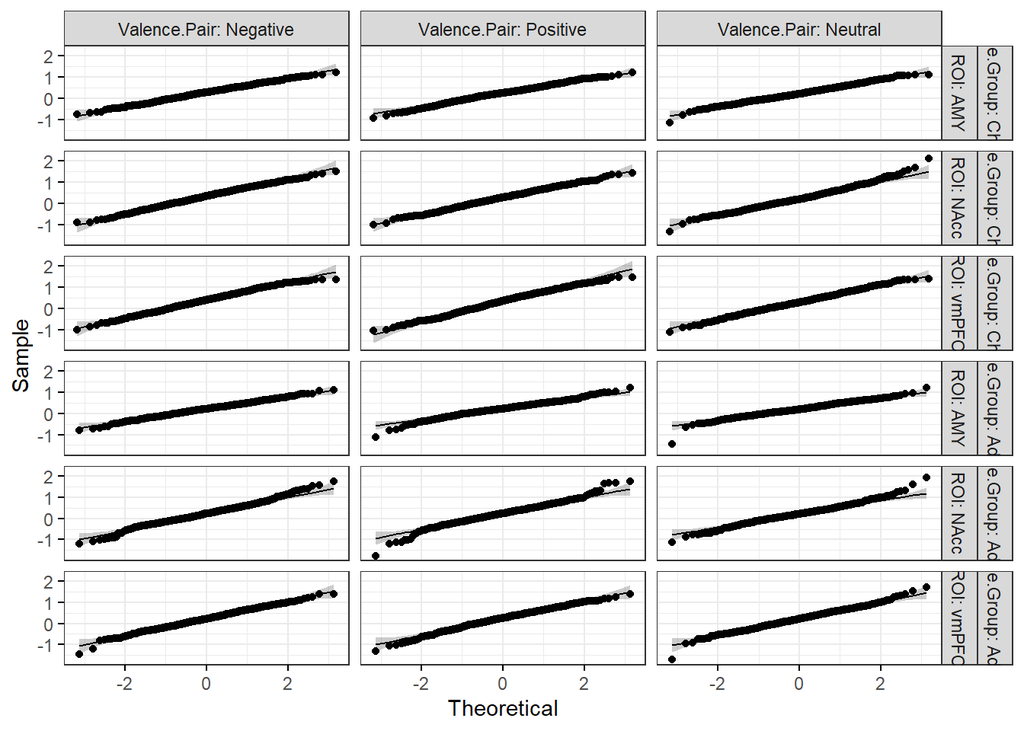

```r
ggqqplot(data = df,
         x = "Correlation.fz",
         ggtheme = theme_bw()) +
         facet_grid(Age.Group + ROI ~ Valence.Pair, labeller = "label_both")
```

As you can see, what we add to the right of the tilde specifies what variable categories we want to see in the columns, and what we add to the left of the tilde specifies what we want to see in the rows. Please note that this facet_grid argument works equally as well with gghistogram as well. Any one argument used within one ggpubr function likely caries over to the other functions within the package, and in fact you will see that the logic of how a lot of these “gg-” visualization packages work are fairly universal across the various packages.

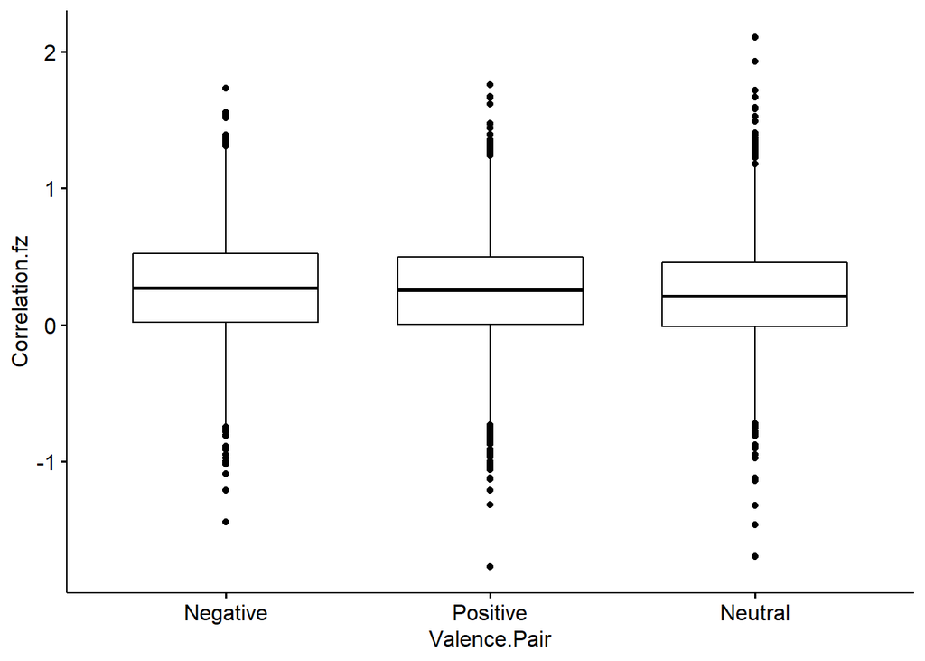

```r
  ggboxplot(df,
            x = "Valence.Pair",
            y = "Correlation.fz")
```

Now, we could get a little more complex and fact by ROI as well:

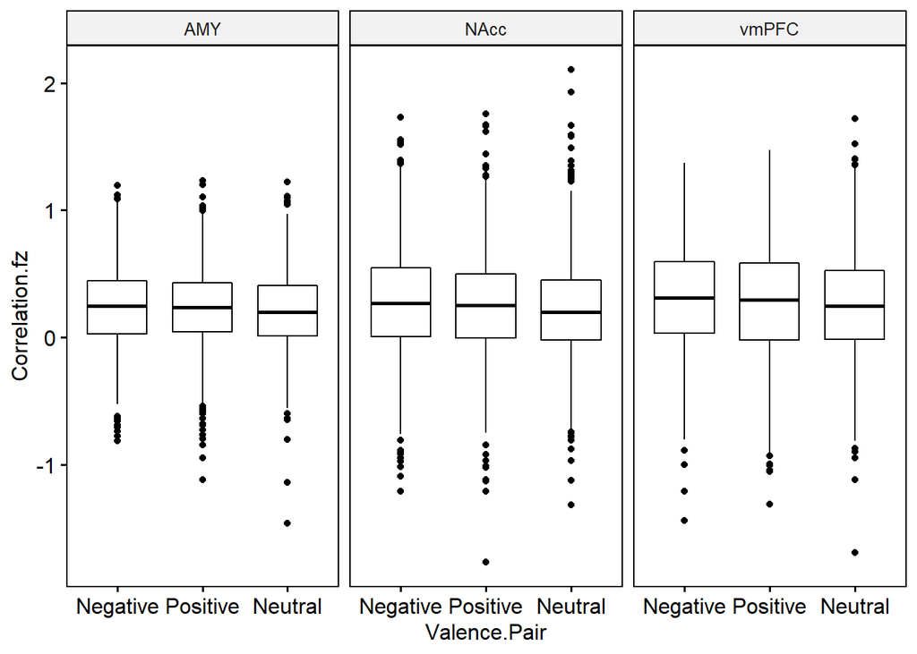

```r
  ggboxplot(df,
            x = "Valence.Pair",
            y = "Correlation.fz",
            facet.by = "ROI")
```

Lastly, let’s get a little crazy and color by age group, and we’ll specify what colors we want to use using the palette command, which accepts basic inputs like “Blue” or fun ggsci palettes, like “rickandmorty” or “simpsons”. We’re just going to keep it boring with “lancet”, though, because the colors chosen for the other two are quite atrocious:

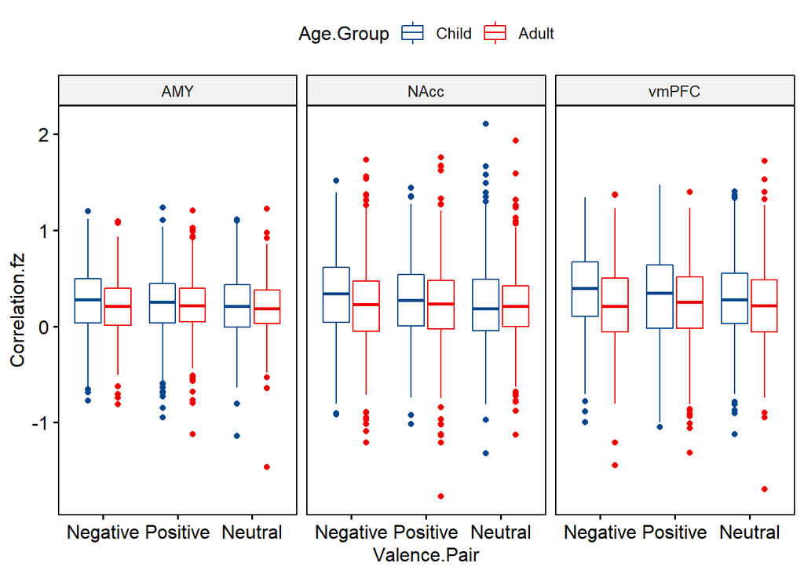

```r
  ggboxplot(df,
            x = "Valence.Pair",
            y = "Correlation.fz",
            color = "Age.Group",
            palette = "lancet",
            facet.by = "ROI")
```

and now we can see with far greater accuracy exactly where our outliers are out lyin’.

Frankly, all of this so far is likely elementary to any researchers who’ve been using R as the default statistics program for some time. We’ll now move on to what many view as the main event in R data visualization: ggplot2, and its many applications.

# 2.0. The Anatomy of a ggplot2 Command

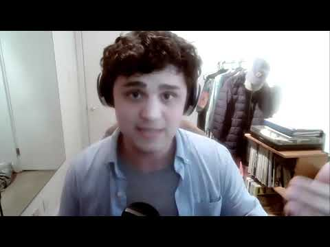

# —– Plot Creation —–

ggplot2 is widely considered the premier data visualization tool for R. As such, the arguments used by the ggplot command are very important to understand. The volume of customization options is frankly overwhelming, but they allow us to produce the beautiful figures that we often see associated with R and are substantially less overwhelming when standardized in a template format. I certainly don’t memorize all of the settings I’ve found to look best and reproduce them everytime I need to plot new data. Instead, I create a template that I can easily copy and paste or recall, and then focus on changing only the details relevant to the data at hand. In this lecture, I’m going to share my standard ggplot template and highlight what all of the arguments do. By the end, you should feel knowledgeable enough to start tweaking the aesthetic qualities of your own plots to find what you feel looks best, and maybe even explore the bevy of additional arguments which I certainly won’t have time to cover within the ggplot documentation.

To start, we’re just going to do a basic regression plot, in which the variable age (in months) predicts pattern similarity, but the actual data doesn’t matter much here. Instead, we’re going to focus on just about everything but the data.

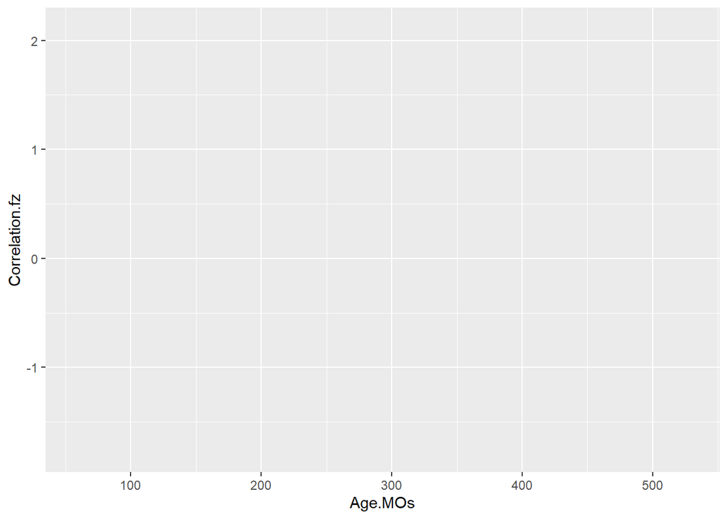

```r
ggplot(df, aes(x = Age.MOs, y = Correlation.fz))
```

This is just about the most basic plot we could run in ggplot. We start by defining the dataframe from which we are pulling our variables (df), and then we tell R which two variables will define the aesthetics of this plot (aes(x = Age.MOs, y = Correlation.fz)). As you can see, and as is common in R, we separate these arguments with a comma, and that’s enough for R to create a basic 2d plane on which we could visualize data. R automatically places the variable we defined as X on the x axis and labels it, and then populates the Y axis as well. Both axes are given reasonable ranges, based on the range of the data.

# —– Adding Geoms —–

However, if we want to see the actual data, we need to define what type of plot (i.e., line, bar, scatter, etc.) we want to see. In order to add more layers to a ggplot, we need to use an addition sign:

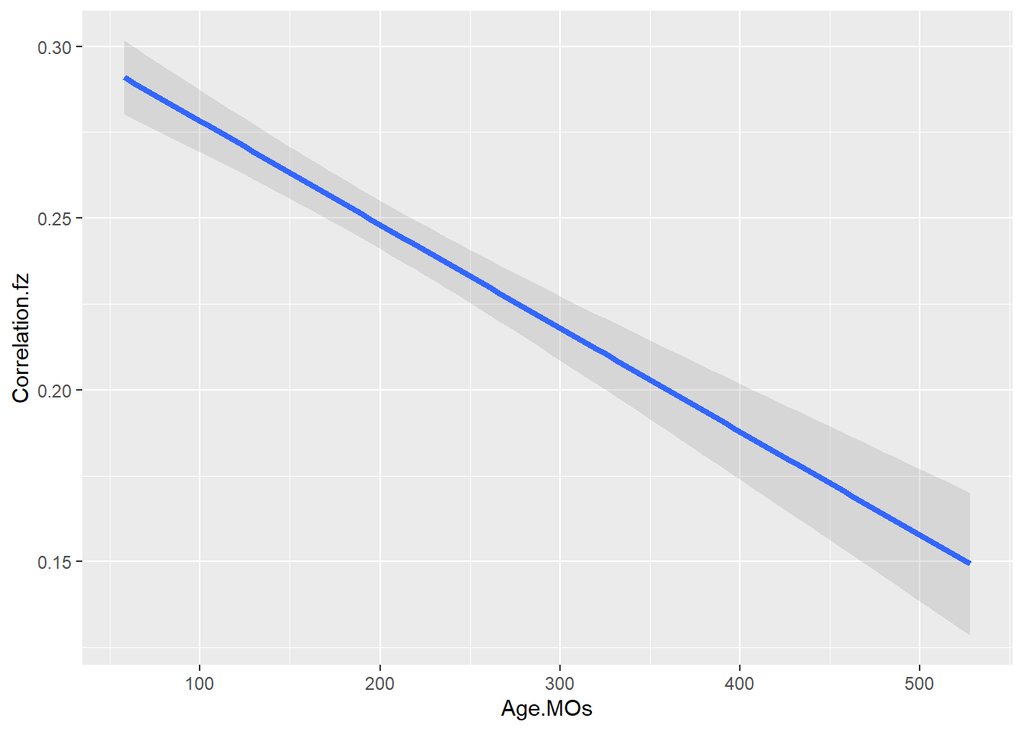

```r
ggplot(df, aes(x = Age.MOs, y = Correlation.fz)) +
    geom_smooth(method="lm", alpha = .25, size = 1.5)
```

Here, we kept the first line the same, and we’re adding a command for ggplot to produce a geometric shape (hence, “geom_”) of the type “smooth” (or a smoothed regression line). There are dozens of possible geoms one could use in ggplot. For reference, you can either check the supplementary inforgraphic I supplied or enter “?ggplot” in the console to review the documentation. Following the command, you’ll see arguments that define the method of smoothing, how dark or light the standard error cloud is around the regression line, and how thick the regression line should be, respectively. These will obviously change quite a bit depending upon the plot, so we’ll dive deeper into these options in a later lecture. For now, I want to move on to commands that I almost always use no matter what type of plot I’m producing.

# —– Labeling Plots —–

The above plot might be perfectly fine for you and your team, who have been looking at the data for months, to understand the relationship your studying, but adding more descriptive labels would go a long way to make these plots more accessible to others. There are a million different commands that will alter the labels of the axes, but I’m partial to this approach, which allows us to modify the title and add subtitles and captions as well:

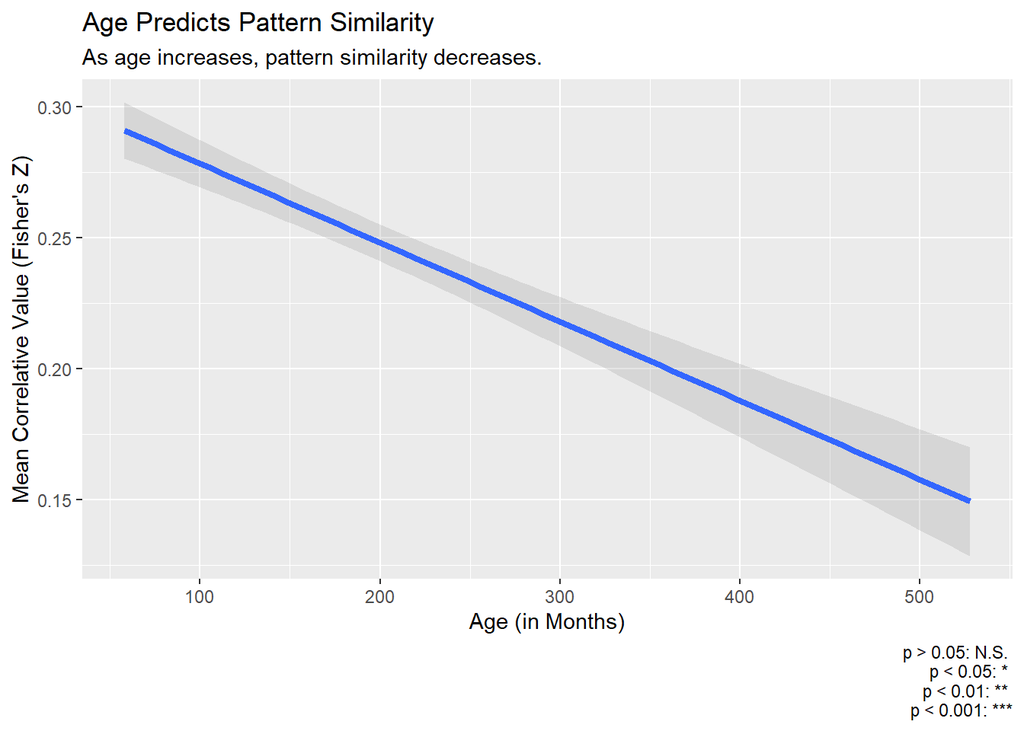

```r
ggplot(df, aes(x = Age.MOs, y = Correlation.fz)) +
    geom_smooth(method="lm", alpha = .25, size = 1.5) +
    labs(title = "Age Predicts Pattern Similarity",
       subtitle = "As age increases, pattern similarity decreases.",
       x = "Age (in Months)",
       y ="Mean Correlative Value (Fisher's Z)",
       caption = "p > 0.05: N.S. \np < 0.05: * \np < 0.01: ** \np < 0.001: ***")
```

# —– Specifying Plot Axes Range —–

This looks better, certainly, but it’s a little disingenuous, because my Y axis should really range from -1 to 1. The coord_cartesian function is by far the best way to manipulate the displayed range of your axes without actually modifying the data (Some other functions will exclude datapoints that sit outside of the range you define, meaning they won’t influence your regression line). We simply define the lower and upper limits of our x (xlim) and/or y (ylim) axis:

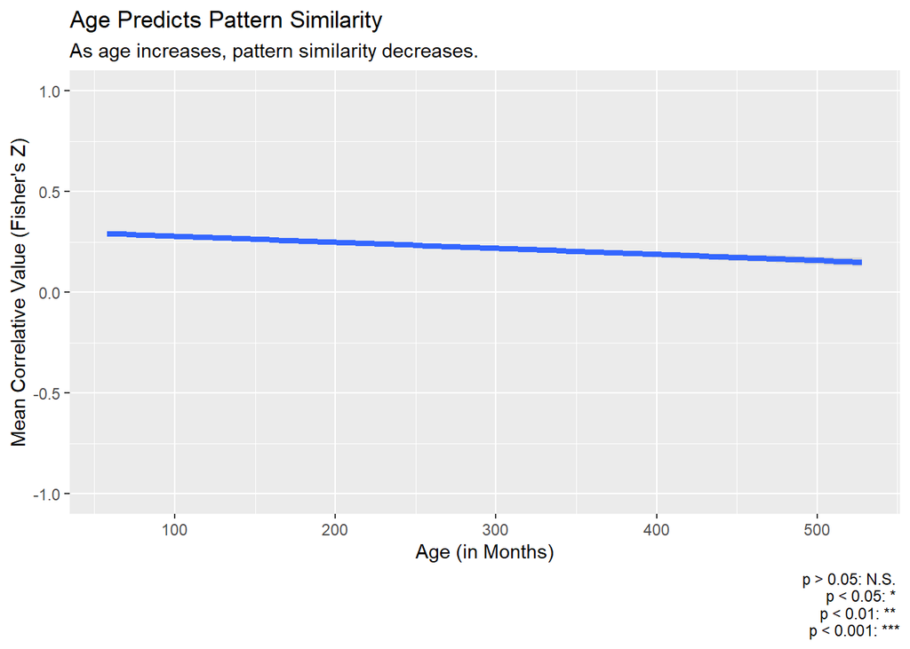

```r
ggplot(df, aes(x = Age.MOs, y = Correlation.fz)) +
    geom_smooth(method="lm", alpha = .25, size = 1.5) +
    labs(title = "Age Predicts Pattern Similarity",
       subtitle = "As age increases, pattern similarity decreases.",
       x = "Age (in Months)",
       y ="Mean Correlative Value (Fisher's Z)",
       caption = "p > 0.05: N.S. \np < 0.05: * \np < 0.01: ** \np < 0.001: ***") +
    coord_cartesian(ylim=c(-1, 1))
```

# —– Using Themes —–

Great! Now the data is all technically correct, but I really don’t like that ugly gray background. Let’s change that with the host of functions that come with the ggtheme package. I believe that base ggplot2 may accept some theme commands without needing ggtheme, but ggtheme, at the least, expands the options we have to customize our plots. We’ll start with my usual favorite, theme_classic:

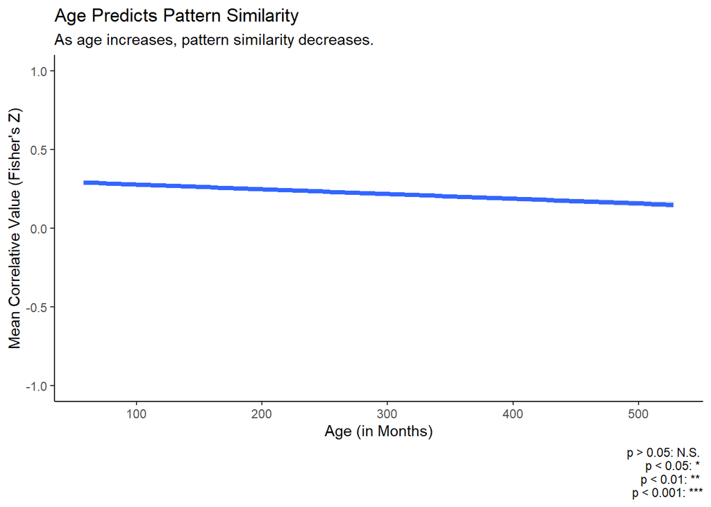

```r
ggplot(df, aes(x = Age.MOs, y = Correlation.fz)) +
    geom_smooth(method="lm", alpha = .25, size = 1.5) +
    labs(title = "Age Predicts Pattern Similarity",
       subtitle = "As age increases, pattern similarity decreases.",
       x = "Age (in Months)",
       y ="Mean Correlative Value (Fisher's Z)",
       caption = "p > 0.05: N.S. \np < 0.05: * \np < 0.01: ** \np < 0.001: ***") +
    coord_cartesian(ylim=c(-1, 1)) +
    theme_classic()
```

The “theme_” commands do an overhaul on the presentation of the plot, and make many changes all at once. Let’s take a look what another few look like

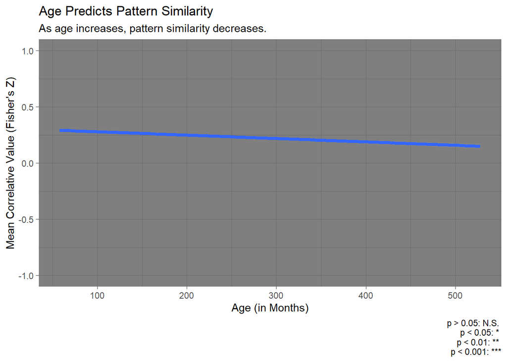

```r
ggplot(df, aes(x = Age.MOs, y = Correlation.fz)) +
    geom_smooth(method="lm", alpha = .25, size = 1.5) +
    labs(title = "Age Predicts Pattern Similarity",
       subtitle = "As age increases, pattern similarity decreases.",
       x = "Age (in Months)",
       y ="Mean Correlative Value (Fisher's Z)",
       caption = "p > 0.05: N.S. \np < 0.05: * \np < 0.01: ** \np < 0.001: ***") +
    coord_cartesian(ylim=c(-1, 1)) +
    theme_dark()
```

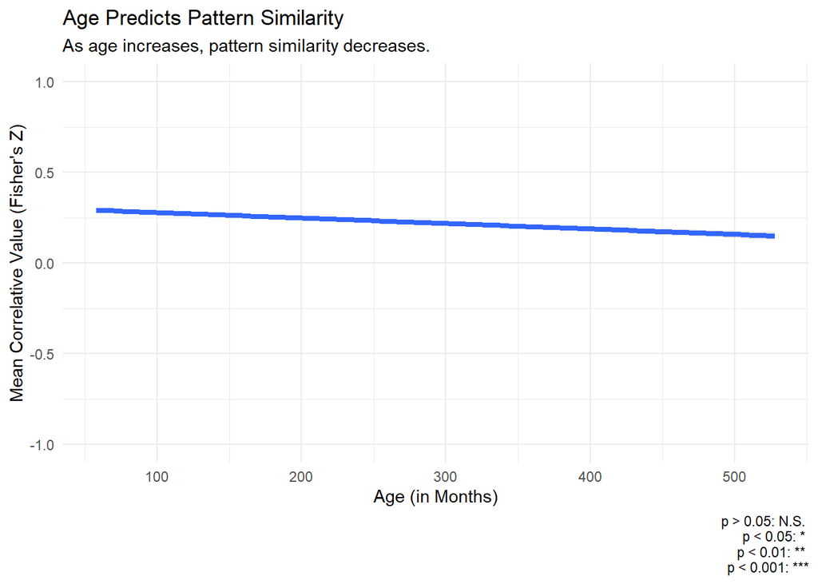

```r
ggplot(df, aes(x = Age.MOs, y = Correlation.fz)) +
    geom_smooth(method="lm", alpha = .25, size = 1.5) +
    labs(title = "Age Predicts Pattern Similarity",
       subtitle = "As age increases, pattern similarity decreases.",
       x = "Age (in Months)",
       y ="Mean Correlative Value (Fisher's Z)",
       caption = "p > 0.05: N.S. \np < 0.05: * \np < 0.01: ** \np < 0.001: ***") +
    coord_cartesian(ylim=c(-1, 1)) +
    theme_minimal()
```

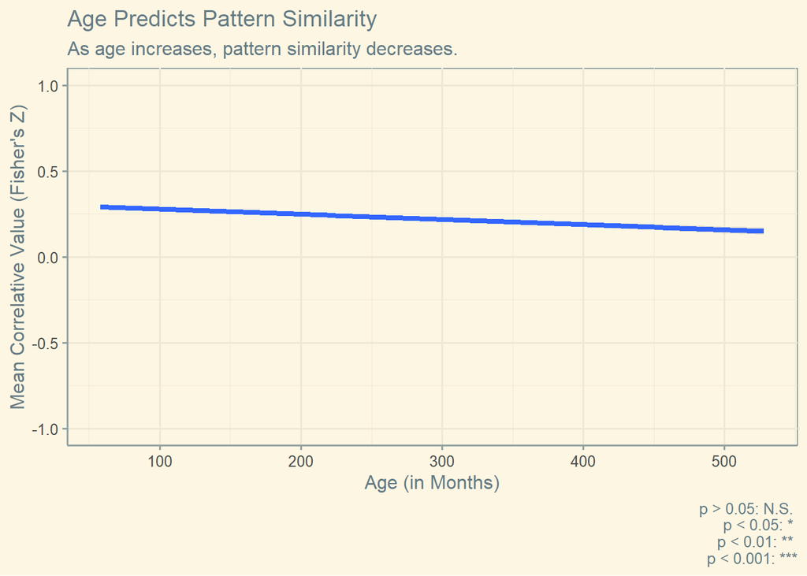

```r
ggplot(df, aes(x = Age.MOs, y = Correlation.fz)) +
    geom_smooth(method="lm", alpha = .25, size = 1.5) +
    labs(title = "Age Predicts Pattern Similarity",
       subtitle = "As age increases, pattern similarity decreases.",
       x = "Age (in Months)",
       y ="Mean Correlative Value (Fisher's Z)",
       caption = "p > 0.05: N.S. \np < 0.05: * \np < 0.01: ** \np < 0.001: ***") +
    coord_cartesian(ylim=c(-1, 1)) +
    theme_solarized()
```

Quite a range! There are a ton of other options which you can review in the ggthemes documentation.

```r
?ggthemes
```

# —– Modifying Text Elements —–

For the sake of time, we’re going to move onto the last thing I usually do, and that’s modify the appearance of the text using theme commands, It drives me nuts that the title is off-center and that the “p”’s in the caption are misaligned, so we’re going to run a series of commands to correct this.

```r
ggplot(df, aes(x = Age.MOs, y = Correlation.fz)) +
    geom_smooth(method="lm", alpha = .25, size = 1.5) +
    labs(title = "Age Predicts Pattern Similarity",
       subtitle = "As age increases, pattern similarity decreases.",
       x = "Age (in Months)",
       y ="Mean Correlative Value (Fisher's Z)",
       caption = "p > 0.05: N.S. \np < 0.05: * \np < 0.01: ** \np < 0.001: ***") +
    coord_cartesian(ylim=c(-1, 1)) +
    theme_classic() +
    theme(plot.title = element_text(face="bold", size=13, hjust = 0.5)) +
    theme(plot.subtitle = element_text(face = "italic", size = 10, hjust = 0.5)) +
    theme(plot.caption = element_text(face = "italic", size = 8, hjust = 0.0)) +
    theme(axis.title = element_text(size = 12)) +
    theme(axis.text.x = element_text(size = 14, color = "Black")) +
    theme(axis.text.y = element_text(size = 14, color = "Black"))
```

[output not shown]

As you can see, we added several new lines that all utilize the theme function. Within each line, we then specify what element of the plot we are targeting, whether it be plot subtitle, plot caption, or anything else. We then note that we are specifically modifying the text of each of these elements. Then, just like with the geom_ series of functions, there are a massive number of argumetns which we could utilize to change the color of the text, the orientation, the size, the face type, the font, and the centering. All of these are also well documented and there are a ton of blogs which can walk you through these. One note on the hjust (centering) argument: A value of 0 left-justifies the text (As we see with the caption), a value of 1 right justifies text, and a value of 0.5 centers it (as we see in the title).

One last note: later layers take precedence. So, if you give ggplot to arguments which affect the same plot element in a conflicting way (maybe you want tell it you want the X axis labeled “Bananas” early on, and then “Apples” at the end), ggplot will often not let you know that these arguments are in conflict, and just accept whatever argument came last (so your X axis will be named Apples). We’re really just sort of scratching the surface of what we can do in R when it comes to visualizations, but hopefully this provides a good foundation for what is still to come. The next two modules will be much quicker and more focused.

# —– Exercise —–

Let’s see you give it a show. Modify the code of the plot below so that the title and subtitle are right justified and the text of both axes appear blue in color.

```r
ggplot(df, aes(x = Age.MOs, y = Correlation.fz)) +
    geom_smooth(method="lm", alpha = .25, size = 1.5) +
    labs(title = "Age Predicts Pattern Similarity",
       subtitle = "As age increases, pattern similarity decreases.",
       x = "Age (in Months)",
       y ="Mean Correlative Value (Fisher's Z)",
       caption = "p > 0.05: N.S. \np < 0.05: * \np < 0.01: ** \np < 0.001: ***") +
    coord_cartesian(ylim=c(-1, 1)) +
    theme_classic() +
    theme(plot.title = element_text(face="bold", size=13, hjust = 0.5)) +
    theme(plot.subtitle = element_text(face = "italic", size = 10, hjust = 0.5)) +
    theme(plot.caption = element_text(face = "italic", size = 8, hjust = 0.0)) +
    theme(axis.title = element_text(size = 12)) +
    theme(axis.text.x = element_text(size = 14, color = "Black")) +
    theme(axis.text.y = element_text(size = 14, color = "Black"))
```

# 3.0. Exporting Figures

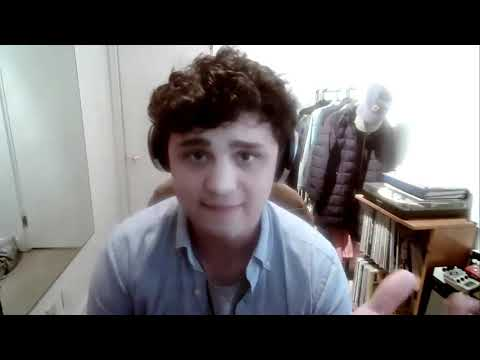

It might seem weird focusing a whole lecture on just exporting your figures. Seems like if should be simple enough, right? and it kind of is. That is to say, if we wanted to export the last plot we created, we could simply right click the image and click “Save as”. However, I’ve always found the quality to be lacking using that method. The plot geoms tend to look pixelated, the colors tend to be off, and the proportions are not what they looked to be in the preview. The best work around I have found uses the following format:

First, we save whatever plot we want to export as a variable. I often just save it as “Plot” so that the script that follows is more standardized.

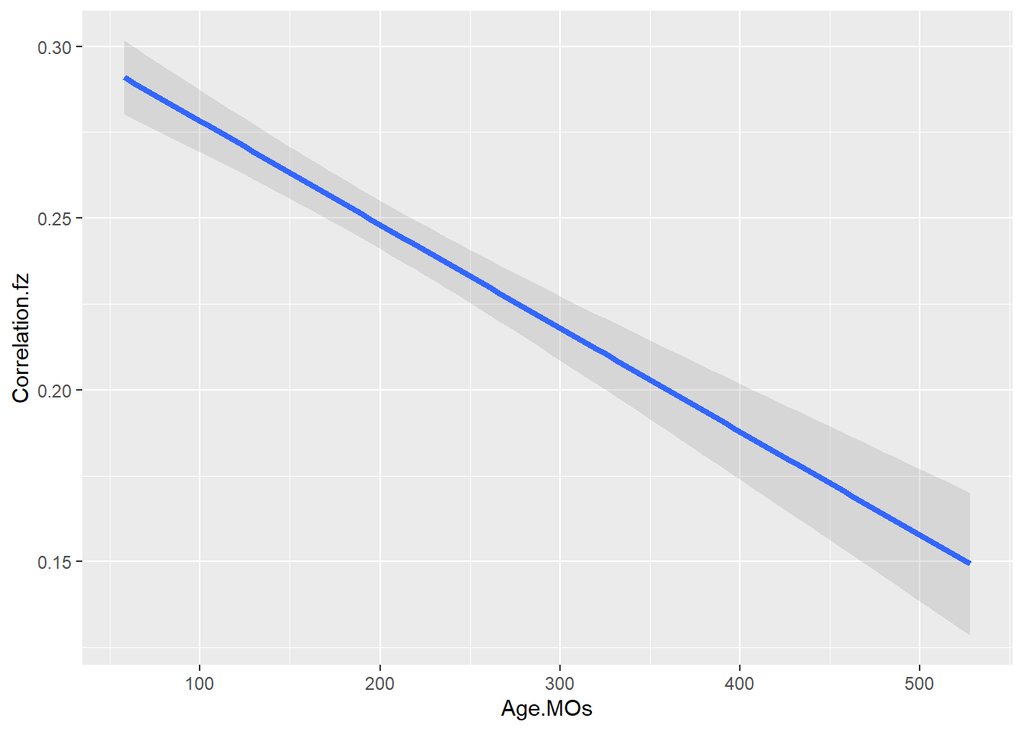

```r
Plot <- ggplot(df, aes(x = Age.MOs, y = Correlation.fz)) +
    geom_smooth(method="lm", alpha = .25, size = 1.5)
Plot
```

Then we use the following script. First, we set the working directory for where we want to save the image. We defined the filepath for Plots.Dir when we set up this script. Then, we tell R that we want to save a pdf under this file name, that will have the dimensions of 6 inches x 4 inches. We then must call what the image is that we are saving under that file name. Lastly, we tell R that we’re done with this action by calling the dev.off() function. I then remove my ploy using the rm(Plot) function to keep my space clean.

```r
  setwd(Plots.Dir)
  pdf("Plot Example.pdf", width = (6), height = (4))
  Plot
  dev.off()
```

```r
  rm(Plot)
```

We then get a beautiful exported image with no pixelation in a pdf format. Unfortunately, pdfs can be a little more difficult incorporating into a manuscript or powerpoint than a traditional lower-resolution image format, but I often just use the Snip & Sketch tool in Windows to quickly convert the images to a .png or .jpeg when needed. Admittedly, it’s not a great solution, but fits in well with my workflow. One advantage of this solution is that I don’t need to manage multiple versions of the same image or worry whether I have the most up-to-date figure. If I make any changes upstream that would affect the appearance of a figure downstream, I simply rerun the whole script and the image overwrites the previous version that existed.

# 4.0. Accessibility and Interpretability Options

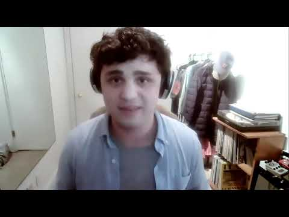

In this module, we’re going to build on the same plot we were just working on, so when you see this:

```r
ggplot(df, aes(x = Age.MOs, y = Correlation.fz)) +
    geom_smooth(method="lm", alpha = .25, size = 1.5) +
    labs(title = "Age Predicts Pattern Similarity",
       subtitle = "As age increases, pattern similarity decreases.",
       x = "Age (in Months)",
       y ="Mean Correlative Value (Fisher's Z)",
       caption = "p > 0.05: N.S. \np < 0.05: * \np < 0.01: ** \np < 0.001: ***") +
    coord_cartesian(ylim=c(-1, 1)) +
    theme_classic() +
    theme(plot.title = element_text(face="bold", size=13, hjust = 0.5)) +
    theme(plot.subtitle = element_text(face = "italic", size = 10, hjust = 0.5)) +
    theme(plot.caption = element_text(face = "italic", size = 8, hjust = 0.0)) +
    theme(axis.title = element_text(size = 12)) +
    theme(axis.text.x = element_text(size = 14, color = "Black")) +
    theme(axis.text.y = element_text(size = 14, color = "Black"))
```

Just know we haven’t changed it in any way yet. When we do make changes to this template, I’ll highlight them by using hashtags and descriptions of what is changing.

# —– Coloring Geoms —–

In the last module, we reviewed a few simple commands we can use to make just about any plot look more presentable. These were things that I do for almost any plot I create, but as we go further into these modules, I’m going to get progressively more niche in the commands I use. Now, as I conceptualize it, we’re at the stage of functions we should certainly always consider, but might not always be right for the situation or data.

To start off, you might notice I was going on and on about how much control ggplot2 gives you in the last module, but I never even changed the color of the regression line. ggplot2 makes it super simple to make quick color changes by just naming it in the geom_smooth command. Let’s say we want the regression line to be red instead:

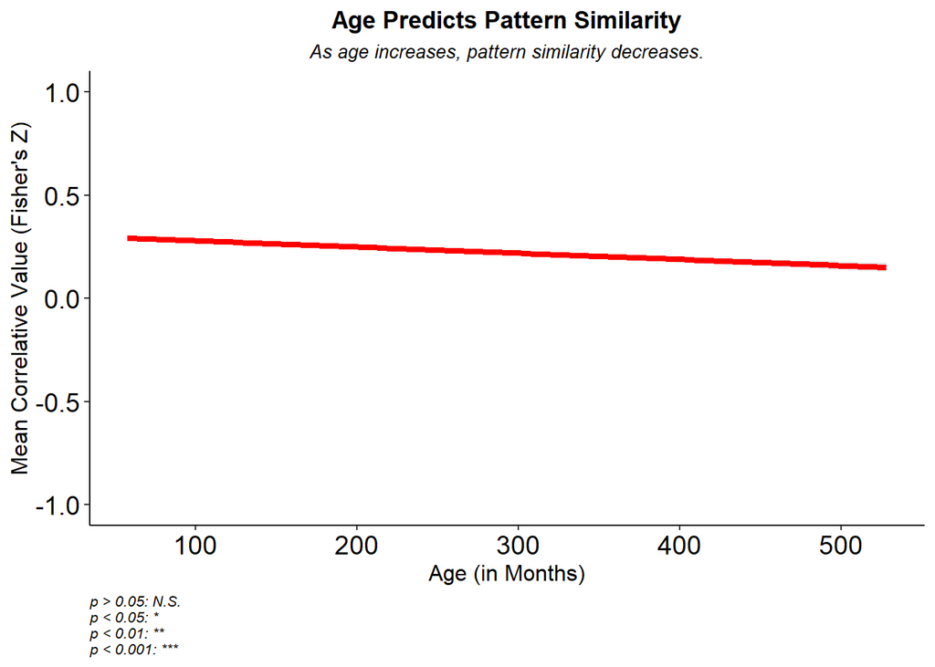

```r
ggplot(df, aes(x = Age.MOs, y = Correlation.fz)) +
    geom_smooth(method="lm", alpha = .25, size = 1.5, color = "Red") + #I added the "color = "Red"" argument here
    labs(title = "Age Predicts Pattern Similarity",
       subtitle = "As age increases, pattern similarity decreases.",
       x = "Age (in Months)",
       y ="Mean Correlative Value (Fisher's Z)",
       caption = "p > 0.05: N.S. \np < 0.05: * \np < 0.01: ** \np < 0.001: ***") +
    coord_cartesian(ylim=c(-1, 1)) +
    theme_classic() +
    theme(plot.title = element_text(face="bold", size=13, hjust = 0.5)) +
    theme(plot.subtitle = element_text(face = "italic", size = 10, hjust = 0.5)) +
    theme(plot.caption = element_text(face = "italic", size = 8, hjust = 0.0)) +
    theme(axis.title = element_text(size = 12)) +
    theme(axis.text.x = element_text(size = 14, color = "Black")) +
    theme(axis.text.y = element_text(size = 14, color = "Black"))
```

We can also use hex codes so as to standardize our colors across programs and platforms:

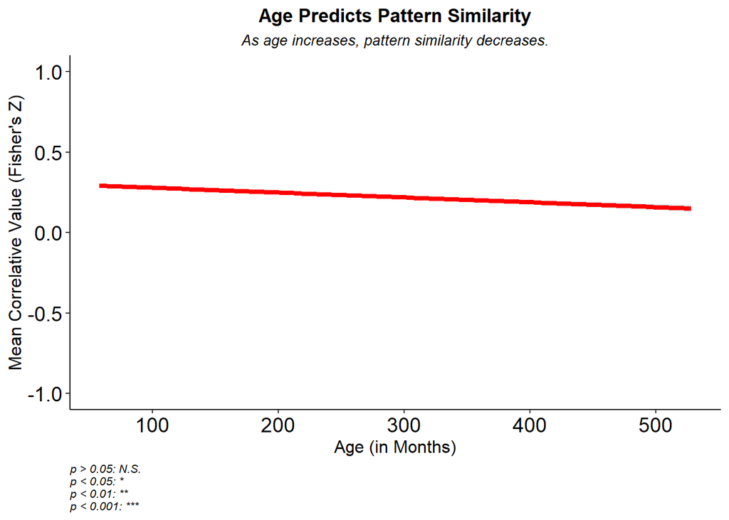

```r
ggplot(df, aes(x = Age.MOs, y = Correlation.fz)) +
    geom_smooth(method="lm", alpha = .25, size = 1.5, color = "#FF0000") + #I added the "color = "#FF0000"" argument here
    labs(title = "Age Predicts Pattern Similarity",
       subtitle = "As age increases, pattern similarity decreases.",
       x = "Age (in Months)",
       y ="Mean Correlative Value (Fisher's Z)",
       caption = "p > 0.05: N.S. \np < 0.05: * \np < 0.01: ** \np < 0.001: ***") +
    coord_cartesian(ylim=c(-1, 1)) +
    theme_classic() +
    theme(plot.title = element_text(face="bold", size=13, hjust = 0.5)) +
    theme(plot.subtitle = element_text(face = "italic", size = 10, hjust = 0.5)) +
    theme(plot.caption = element_text(face = "italic", size = 8, hjust = 0.0)) +
    theme(axis.title = element_text(size = 12)) +
    theme(axis.text.x = element_text(size = 14, color = "Black")) +
    theme(axis.text.y = element_text(size = 14, color = "Black"))
```

This is helpful if we’re planning on publishing in a journal that doesn’t use color figures, or we want to keep our figures of a certain theme. We can even get a little more fancy and add gradients to our plots like this:

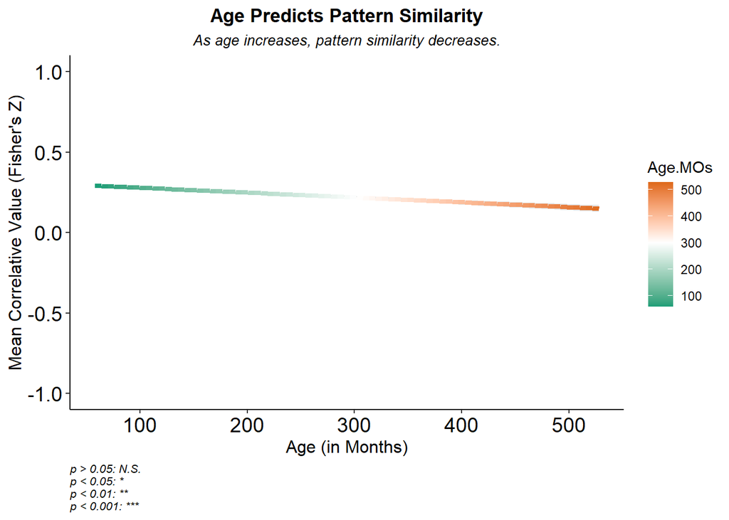

```r
ggplot(df, aes(x = Age.MOs, y = Correlation.fz, color = Age.MOs)) + #I added the argument "color = Age.MOs" so that color should be applied to visualizations related to my x variable
    geom_smooth(method="lm", alpha = .25, size = 1.5, aes(color = ..x..)) + #I honestly don't know why I need an aes() argument here, but I change color to "..x.."
    scale_color_gradient2(low = "#1B9E77", high = "#D95F02", midpoint = 300) + # This function is new. I note the colors on the low and high ends, and then note where the colors blend.
    labs(title = "Age Predicts Pattern Similarity",
       subtitle = "As age increases, pattern similarity decreases.",
       x = "Age (in Months)",
       y ="Mean Correlative Value (Fisher's Z)",
       caption = "p > 0.05: N.S. \np < 0.05: * \np < 0.01: ** \np < 0.001: ***") +
    coord_cartesian(ylim=c(-1, 1)) +
    theme_classic() +
    theme(plot.title = element_text(face="bold", size=13, hjust = 0.5)) +
    theme(plot.subtitle = element_text(face = "italic", size = 10, hjust = 0.5)) +
    theme(plot.caption = element_text(face = "italic", size = 8, hjust = 0.0)) +
    theme(axis.title = element_text(size = 12)) +
    theme(axis.text.x = element_text(size = 14, color = "Black")) +
    theme(axis.text.y = element_text(size = 14, color = "Black"))
```

I will sometimes do this if the bivariate regression I’m presenting is leading to a moderation analysis, using the colors I used to distinguish the moderator levels on the gradient.

# —– Facet Wrapping —–

Speaking of moderators, though, let’s talk about facet wrapping. We’d mentioned it a little earlier when looking at assumption visualizations, and it can be useful in ggplot2, especially when we have multiple moderating factors that might be influencing a relationship. Let’s pretend that we think that the valence of the stimuli might moderate the relationship between age and pattern similarity and, for whatever reason, we want to see it in separate panels. We can add three more functions to do that:

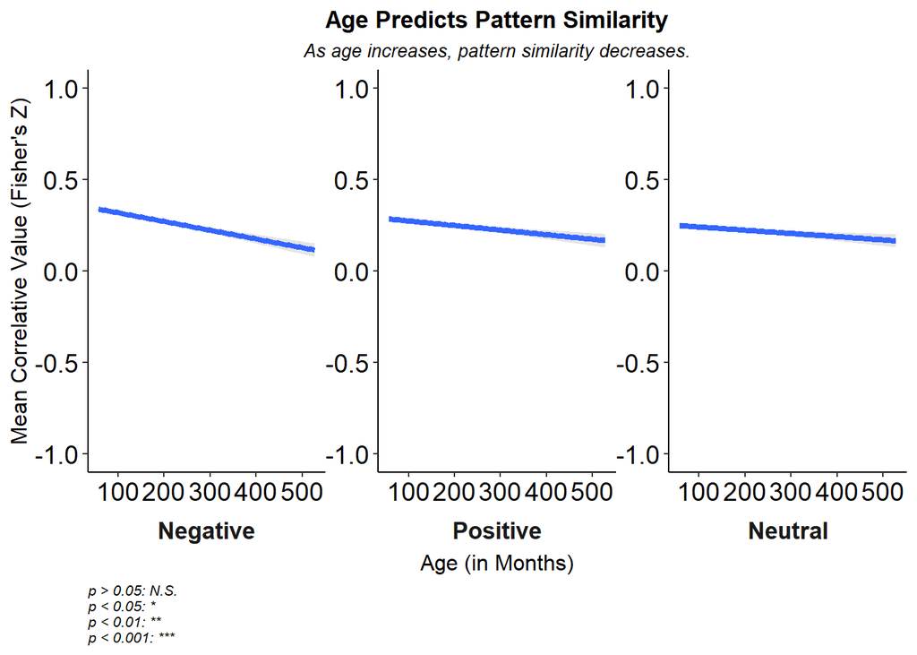

```r
ggplot(df, aes(x = Age.MOs, y = Correlation.fz)) +
    geom_smooth(method="lm", alpha = .25, size = 1.5) +
    labs(title = "Age Predicts Pattern Similarity",
       subtitle = "As age increases, pattern similarity decreases.",
       x = "Age (in Months)",
       y ="Mean Correlative Value (Fisher's Z)",
       caption = "p > 0.05: N.S. \np < 0.05: * \np < 0.01: ** \np < 0.001: ***") +
    coord_cartesian(ylim=c(-1, 1)) +
    theme(legend.position="none") +   # This will suppress the production of a superfluous legend
    facet_wrap(.~Valence.Pair, scales='free', strip.position = "bottom") + # This facets the plot based upon the variable you note
    theme_classic() +
    theme(plot.title = element_text(face="bold", size=13, hjust = 0.5)) +
    theme(plot.subtitle = element_text(face = "italic", size = 10, hjust = 0.5)) +
    theme(plot.caption = element_text(face = "italic", size = 8, hjust = 0.0)) +
    theme(axis.title = element_text(size = 12)) +
    theme(axis.text.x = element_text(size = 14, color = "Black")) +
    theme(axis.text.y = element_text(size = 14, color = "Black")) +
    theme(panel.spacing = unit(0, "points"), # This command modifies the appearance and distancing of the faceting.
          strip.background = element_blank(),
          strip.placement  = "outside",
          strip.text = element_text(size=13,face = 'bold'))
```

The resulting plot might look a little squished on your display. You can better view it in a pop-out window using the first option in the output box to get a better look at it. Either way, we can now clearly see what this relationship looks like as moderated by valence. We can get even more complex and add a second moderator (ROI) with ease.

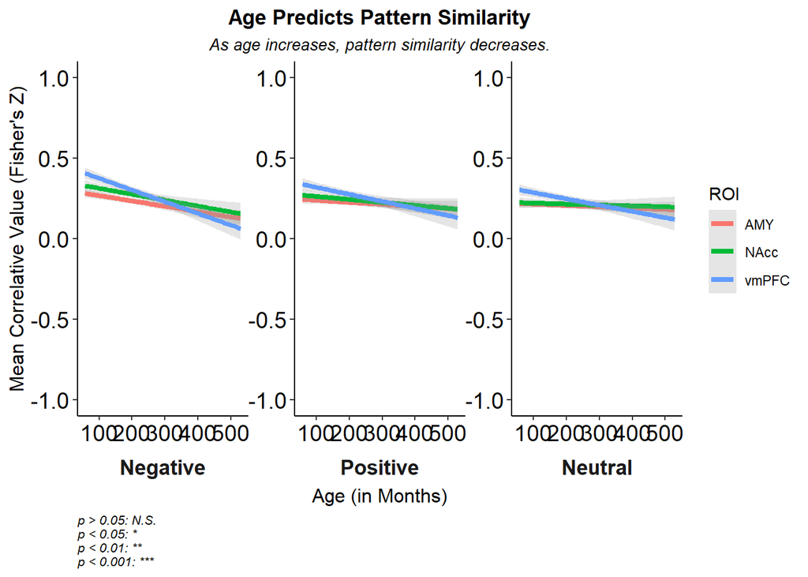

```r
ggplot(df, aes(x = Age.MOs, y = Correlation.fz, group = ROI, color = ROI)) + #I'm letting R know that there's an additional variable (ROI) that I'd like it to group the data of the other two variables by and to color the resulting plots by.
    geom_smooth(aes(group = ROI), method="lm", alpha = .25, size = 1.5) + # By adding aes(group = ROI), I'm letting R know I want it to produce a different geom_smooth regression line for each level of ROI
    labs(title = "Age Predicts Pattern Similarity",
       subtitle = "As age increases, pattern similarity decreases.",
       x = "Age (in Months)",
       y ="Mean Correlative Value (Fisher's Z)",
       caption = "p > 0.05: N.S. \np < 0.05: * \np < 0.01: ** \np < 0.001: ***") +
    coord_cartesian(ylim=c(-1, 1)) +
    theme(legend.position="none") +
    facet_wrap(.~Valence.Pair, scales='free', strip.position = "bottom") +
    theme_classic() +
    theme(plot.title = element_text(face="bold", size=13, hjust = 0.5)) +
    theme(plot.subtitle = element_text(face = "italic", size = 10, hjust = 0.5)) +
    theme(plot.caption = element_text(face = "italic", size = 8, hjust = 0.0)) +
    theme(axis.title = element_text(size = 12)) +
    theme(axis.text.x = element_text(size = 14, color = "Black")) +
    theme(axis.text.y = element_text(size = 14, color = "Black")) +
    theme(panel.spacing = unit(0, "points"),
          strip.background = element_blank(),
          strip.placement  = "outside",
          strip.text = element_text(size=13,face = 'bold'))
```